# Text as Data HW 3

Chenjie Su cs5998

4/28/2020

```r
# setting up the environment
rm(list = ls())
setwd('/Users/chenjiesu/Desktop/Text_as_Data_Assignments/HW3')#set work directory
```

```r
# import libraries
library(quanteda)
library(quanteda.corpora)
library(dplyr)
library(topicmodels)
library(lda)
library(stm)
```

```r
library(tidytext)
library(ggplot2)
library(text2vec)
library(stm)
library(bursts)
library(readtext)
library(factoextra)
library(lsa)
library(Rtsne)
library(rsvd)
library(geometry)
```

### Q1a

```r
immigrationnews <- data_corpus_immigrationnews
# head(summary(immigrationnews),10)
# Select the articles from the news source requested in the question
new_im_news <- corpus_subset(immigrationnews, paperName == "telegraph"| paperName == "guardian" | paperName == "ft" | paperName ==  "independent" | paperName == "express")
articles_count = aggregate(id~paperName, data=as.data.frame(new_im_news$documents), length)
articles_count
```

| paperName | id |
| --- | --- |
| express | 325 |
| ft | 207 |
| guardian | 392 |
| independent | 324 |
| telegraph | 511 |

### Q1b

```r
# Create a document term matrix
custom_stopwords <- load("/Users/chenjiesu/Desktop/Text_as_Data_Assignments/HW3/custom_stopwords.RData")
news_dfm <- dfm(new_im_news,remove_punct = TRUE, remove_numbers = TRUE, stem =TRUE, tolower=TRUE, remove=c(stopwords("english"), custom_stopwords))
# dfm trim
news_dfm_trim<- dfm_trim(news_dfm, min_termfreq = 30, min_docfreq=20)
# Report the remaining number of features and the total number of documents in the DFM
news_dfm_trim
```

```
## Document-feature matrix of: 1,759 documents, 2,998 features (92.7% sparse).
```

### Q1c

Preprocessing decisions can have substantive impacts on the topics created by topic model algorithms. Make a brief (1 paragraph) argument for or against removing rare terms from a dfm on which you plan to fit a topic model.

**I think removing rare terms from a dfm is a good choice since some rare terms model can’t represent a topic and will influence the performance of the modle. Without the rare terms, the LDA model can generate the number of topics more percisely.**

### Q1d

```r
# use the parameters to fit the model
topics_n <- 25
topic_model <- LDA(news_dfm_trim, k=topics_n, method='Gibbs', control=list(seed=1234, iter=3000))
# report he loglikelihood
print(paste0("the loglikelihood for the topic model is: ", topic_model@loglikelihood))
```

```
## [1] "the loglikelihood for the topic model is: -3443864.68878936"
```

### Q1e

```r
# top 10 words to each topic
top_words <- get_terms(topic_model,k=10)
# glimpse the top words
top_words
```

```
##       Topic 1 Topic 2    Topic 3    Topic 4   Topic 5  Topic 6   Topic 7
##  [1,] "say"   "independ" "parti"    "per"     "london" "immigr"  "guardian"
##  [2,] "peopl" "bbc"      "ukip"     "cent"    "citi"   "migrat"  "right"
##  [3,] "think" "print"    "vote"     "peopl"   "one"    "year"    "page"
##  [4,] "go"    "reserv"   "elect"    "minor"   "hous"   "figur"   "reserv"
##  [5,] "get"   "right"    "voter"    "like"    "day"    "migrant" "media"
##  [6,] "want"  "radio"    "labour"   "increas" "new"    "britain" "word"
##  [7,] "just"  "newspap"  "support"  "ethnic"  "year"   "number"  "english"
##  [8,] "like"  "word"     "polit"    "year"    "town"   "said"    "document"
##  [9,] "dont"  "show"     "european" "group"   "time"   "uk"      "id"
## [10,] "can"   "id"       "poll"     "number"  "two"    "net"     "news"
##       Topic 8     Topic 9      Topic 10  Topic 11   Topic 12 Topic 13
##  [1,] "immigr"    "eu"         "tax"     "busi"     "book"   "mr"
##  [2,] "worker"    "european"   "hous"    "compani"  "play"   "cameron"
##  [3,] "employ"    "europ"      "economi" "year"     "life"   "tori"
```

[output cut: 29 more lines]

```r
# find the most likely topic for each document
topics <- topics(topic_model)
# glimpse the topics
head(topics)
```

```
## text1 text2 text3 text4 text5 text6
##     3     5    17    17    18    21
```

```r
# Create a table
table_q1e <- as.data.frame(table(topics))
colnames(table_q1e) <- c("Topic_Numbers","Number_of_Documents")
table_q1e <- table_q1e[order(table_q1e$Number_of_Documents,decreasing=T),]
table_q1e
```

|  | Topic_Numbers | Number_of_Documents |
| --- | --- | --- |
| 12 | 12 | 141 |
| 3 | 3 | 125 |
| 6 | 6 | 117 |
| 19 | 19 | 112 |
| 17 | 17 | 103 |
| 13 | 13 | 97 |
| 18 | 18 | 92 |
| 9 | 9 | 88 |
| 22 | 22 | 87 |
| 8 | 8 | 76 |

[output cut: 15 more lines]

```r
# label the topics
label_q1e <- head(table_q1e,5)
label <- c("Entertainment","Vote","Immigration","Race","Scotland")
label_q1e <- cbind(label_q1e,label)
label_q1e
```

|  | Topic_Numbers | Number_of_Documents | label |
| --- | --- | --- | --- |
| 12 | 12 | 141 | Entertainment |
| 3 | 3 | 125 | Vote |
| 6 | 6 | 117 | Immigration |
| 19 | 19 | 112 | Race |
| 17 | 17 | 103 | Scotland |

**The above is the label I made. Here are some interesting top words can represent in the most frequency topics: 12-book, play, stori, film; 3-vote, elect, voter; 6-immigr, migrat, uk; 19-peopl, racist, nigel; 17- scotland, uk, english, scittish, benefit.**

### Q1f

```r
# Store the results of the mixture of documents over topics
doc_topics <- topic_model@gamma
# Store the results of words over topics
#words_topics <- blm_tm@beta
# Transpose the data so that the days are columns
doc_topics <- t(doc_topics)
dim(doc_topics)
```

```
## [1]   25 1759
```

```r
doc_topics[1:5,1:5]
```

```
##             [,1]  [,2]        [,3]       [,4]       [,5]
## [1,] 0.016194332 0.112 0.081818182 0.01935484 0.01438849
## [2,] 0.008097166 0.012 0.006060606 0.03870968 0.02877698
## [3,] 0.242914980 0.008 0.012121212 0.01935484 0.01079137
## [4,] 0.020242915 0.008 0.018181818 0.03225806 0.03237410
## [5,] 0.026315789 0.168 0.160606061 0.03225806 0.02877698
```

```r
# Arrange topics
# Find the top topic per column (day)
max <- apply(doc_topics, 2, which.max)
# Write a function that finds the second max
which.max2 <- function(x,k=25){
  which(x == sort(x,partial=(k-1))[k-1])
}
max2 <- apply(doc_topics, 2, which.max2)
max2 <- sapply(max2, max)
```

```r
# Combine data
top2 <- data.frame(max = max, max2 = max2, date = new_im_news$documents$day, paperName =  new_im_news$documents$paperName)
head(top2)
```

|  | max | max2 | date | paperName |
| --- | --- | --- | --- | --- |
| 1 | 3 | 16 | 100 | express |
| 2 | 5 | 20 | 104 | express |
| 3 | 17 | 5 | 104 | express |
| 4 | 17 | 6 | 104 | express |
| 5 | 18 | 17 | 106 | express |
| 6 | 21 | 17 | 106 | express |

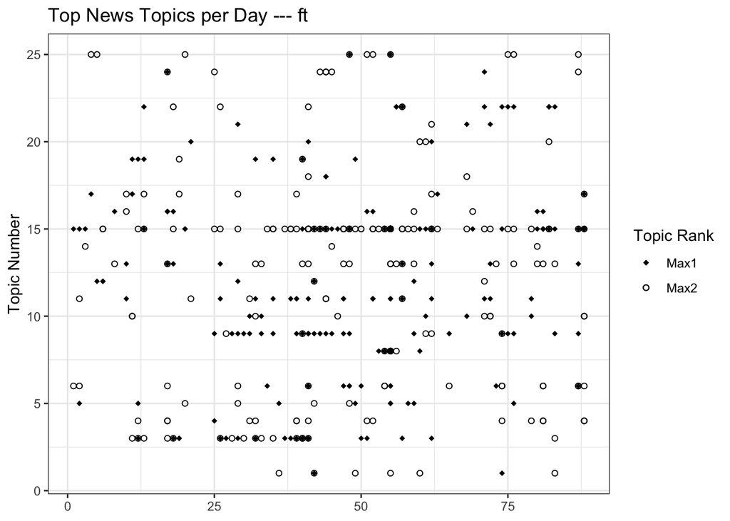

```r
#get the subsets of data: ft, independent
sub_ft <- top2[top2$paperName == "ft",]
sub_id <- top2[top2$paperName == "independent",]
#sort data subset by time
sub_ft$date <- as.numeric(sub_ft$date)
sub_ft <- sub_ft[order(sub_ft$date),]
sub_id$date <- as.numeric(sub_id$date)
sub_id <- sub_id[order(sub_id$date),]
#plot
ft_plot <- ggplot(sub_ft, aes(x=date, y=max, pch="Max1"))
ft_plot + geom_point(aes(x=date, y=max2, pch="Max2") ) +theme_bw() +
  ylab("Topic Number") + ggtitle("Top News Topics per Day --- ft") +geom_point() +
  xlab(NULL) + scale_shape_manual(values=c(18, 1), name = "Topic Rank")
```

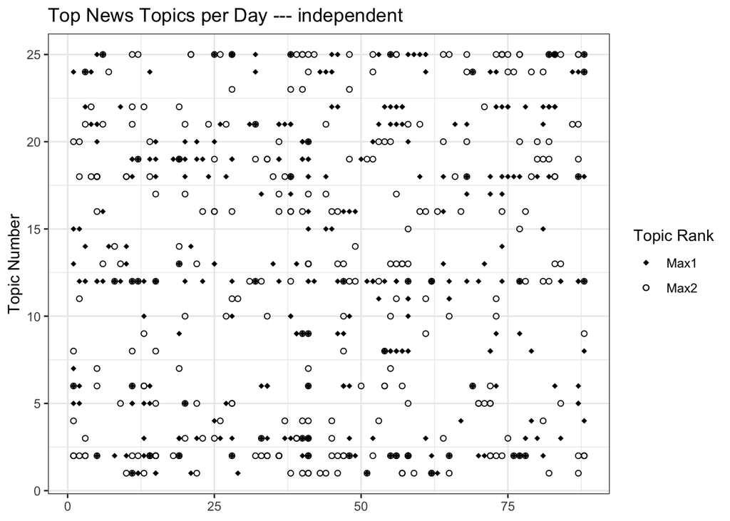

```r
#independent
id_plot <- ggplot(sub_id, aes(x=date, y=max, pch="Max1"))
id_plot + geom_point(aes(x=date, y=max2, pch="Max2") ) +theme_bw() +
  ylab("Topic Number") + ggtitle("Top News Topics per Day --- independent") +geom_point() +
  xlab(NULL) + scale_shape_manual(values=c(18, 1), name = "Topic Rank")
```

**The point distribution of the second graph is relatively uniform. For docs in the ft, there are many texts have the topic 15. There do exist different patterns in different kinds of newspaper which means they are focusing on different topics.**

### Q1g

```r
topics_df <- data.frame(topic_model@gamma)
names(topics_df) <- seq(1:25)
topics_df_ <- topics_df[,c(12,3,6,19,17)]
topics_df_$paperName <- new_im_news$documents$paperName
agg_topics <- aggregate(cbind(topics_df_$`12`, topics_df_$`3`, topics_df_$`6`, topics_df_$`19`,
                              topics_df_$`17`)~paperName, data=topics_df_, FUN = mean)
names(agg_topics) <- c('paperName', 12,3,6,19,17)
agg_topics
```

| paperName | 12 | 3 | 6 | 19 | 17 |
| --- | --- | --- | --- | --- | --- |
| express | 0.03273097 | 0.04038999 | 0.07156743 | 0.04165427 | 0.09997470 |
| ft | 0.02617670 | 0.06064984 | 0.05217376 | 0.03233019 | 0.02582310 |
| guardian | 0.06657049 | 0.05785174 | 0.03816138 | 0.04233786 | 0.02421186 |
| independent | 0.06578631 | 0.04227423 | 0.04282545 | 0.04329377 | 0.02540566 |
| telegraph | 0.04184534 | 0.04133096 | 0.05250108 | 0.04797323 | 0.02909325 |

** For a particular newspaper on particular topics, the values could be very different. Since every newspaper have their own characteristics. For example, I set topic 12 as entertainment, guardian and independent have the most prevalence of topic 12. Maybe they are the newspaper which care about people’s lifestyle more than others.**

### Q2

*Topic stability: We want to see how stable these topics are, under two different topic parameter values.*

### Q2a

```r
# choose seed = 2020
topics_n <- 25
topicmodel <- LDA(news_dfm_trim, k=topics_n, method='Gibbs', control=list(seed=2020, iter=3000))
# report he loglikelihood
print(paste0("The loglikelihood for the topic model is: ", topicmodel@loglikelihood))
```

```
## [1] "The loglikelihood for the topic model is: -3432119.34875297"
```

### Q2b, c

For each topic in the new model, find the topic that is the closest match in the original run in terms of cosine similarity of the topic distribution over words. Your answer should be a table.

Calculate the number of words in the top 10 words shared by each matched topic pair. Your answer should be a table.

```r
match <- function(tm1, tm2,topic_num){
  topic2_words <- tm1@beta
  topic1_words <- tm2@beta
  cos_sim <- as.data.frame.matrix(sim2(x = topic2_words, y = topic1_words, method = "cosine"))

  cos_sim$closest_match <- seq(1:ncol(cos_sim))[apply(cos_sim,1, which.max)]
  match_result <- data.frame(cbind(seq(1:nrow(cos_sim)), cos_sim$closest_match))
  names(match_result) <- c("tm_1","tm_2")

  print(match_result)

  news_tidy_topics <- tidy(tm1, matrix = "beta")
  top10_words_tm1 <- news_tidy_topics %>%
    group_by(topic) %>%
    top_n(10, beta) %>%
    ungroup() %>%
    arrange(topic, -beta)

  news_tidy_topics2 <- tidy(tm2, matrix = "beta")
  top10_words_tm2 <- news_tidy_topics2 %>%
    group_by(topic) %>%
    top_n(10, beta) %>%
    ungroup() %>%
    arrange(topic, -beta)

for (i in 1:topic_num){
  #print(i)
  topic_tm1 = as.numeric(match_result$tm_1[i])
  topic_tm2 = as.numeric(match_result$tm_2[i])

  word_tm1 = top10_words_tm1$term[top10_words_tm1['topic'] == topic_tm1]
  word_tm2 = top10_words_tm2$term[top10_words_tm2['topic'] == topic_tm2]

  num_match = length(intersect(word_tm1, word_tm2))
  match_result$avg_match[i] = num_match
  #print(word_tm1)
  #print(word_tm2)
  #print(topic_tm1)
}

  print(match_result)
  #return(match_result)

}

match(topic_model, topicmodel,25)
```

```
##    tm_1 tm_2
## 1     1    5
## 2     2    3
## 3     3   21
## 4     4    2
## 5     5   19
## 6     6   16
## 7     7   10
## 8     8   13
## 9     9   25
## 10   10   24
## 11   11   14
## 12   12   20
## 13   13   18
## 14   14    2
```

[output cut: 37 more lines]

### Q2d

Now run two more models, but this time, use only 5 topics. Again, find the average number of words in the top ten shared by each matched topic pair. How stable are the models with 5 topics compared to the models with 25 topics?

```r
# run two more models, use only 5 topics
topic_n <- 5
topic_model_1 <- LDA(news_dfm_trim, k=topic_n, method='Gibbs', control=list(seed=1234, iter=3000))
topic_model_2 <- LDA(news_dfm_trim, k=topic_n, method='Gibbs', control=list(seed=2020, iter=3000))
match(topic_model_1, topic_model_2, 5)
```

```
##   tm_1 tm_2
## 1    1    1
## 2    2    5
## 3    3    3
## 4    4    2
## 5    5    4
##   tm_1 tm_2 avg_match
## 1    1    1        10
## 2    2    5         9
## 3    3    3         9
## 4    4    2        10
## 5    5    4         9
```

### Q3

*Topic Models with covariates* **The Structural Topic Model (STM) is designed to incorporate document-level variables into a standard topic model. Since, we have information about both the newspaper and the date of the articles, we can use an STM (from the stm package) to model the effects of these covariates directly.**

### Q3a

```r
news_select_q3 <- corpus_subset(data_corpus_immigrationnews, paperName ==  "guardian" | paperName == "ft")
news_q3_date <- as.numeric(news_select_q3$documents$day)
news_select_q3$documents$day <- as.numeric(news_select_q3$documents$day)
news_q3_dfm <- dfm(news_select_q3,remove_punct = TRUE, remove_numbers = TRUE,stem = TRUE,tolower=TRUE,remove=c(stopwords("english"), custom_stopwords))
```

**I choose to remove the punctuations, numbers and stopwords, also, stem all the words and convert all the words to lowercase.**

### Q3b

```r
# get the data
news_q3_df = as.data.frame(cbind(news_select_q3$documents$texts, news_select_q3$documents$day, news_select_q3$documents$paperName))
names(news_q3_df) <- c("texts", "day", "paperName")
news_q3_df$paperName <- as.factor(news_q3_df$paperName)
news_q3_df$day <- as.numeric(news_q3_df$day)
## fit a STM model
stm_news <- stm(news_q3_dfm, K=0, init.type='Spectral', seed=100, prevalence =~paperName + s(day), data=news_q3_df, reportevery = 10)
```

[output not shown]

[output cut: 1204 more lines]

```
##  Topic 109: peopl, work, guardian, cultur, can
##  Topic 110: parti, ukip, mep, farag, said
##  Topic 111: financi, time, ft, post, articl
##  Topic 112: water, singapor, countri, risk, polit
##  Topic 113: student, uk, univers, intern, studi
##  Topic 114: say, peopl, ami, said, guardian
##  Topic 115: guardian, interview, greec, golden, dawn
## .......................................................................................................................
## Completed E-Step (4 seconds).
## Completed M-Step.
## Completing Iteration 81 (approx. per word bound = -6.555, relative change = 7.914e-05)
## .......................................................................................................................
## Completed E-Step (4 seconds).
## Completed M-Step.
## Model Converged
```

```r
#saveRDS(stm_news,"mystm.rds")
#save.image("myworkspace.RData")
#load("myworkspace.RData")
```

```r
# Report the number of topics selected in the fitted model.
# Also report the number of iterations completed before the model converged.
stm_topics <- data.frame(stm_news$theta)
print(paste0("The number of topics selected in the fitted model is:", ncol(stm_topics)))
```

```
## [1] "The number of topics selected in the fitted model is:115"
```

```r
print(paste0("The number of iteration completed before model converged is:", stm_news$convergence$its))
```

```
## [1] "The number of iteration completed before model converged is:82"
```

### Q3c

Identify and name each of the 5 topics that occur in the highest proportion of documents using the following code: plot(fit.stm, type = “summary”)

[figure not shown]

```r
plot(stm_news, type="summary", n=5, xlim = c(0.02, 0.08))
```

**So I think topic 70 take the highest proportion of the documents. It includes the terms: migrat, net, immigr, uk, figur.**

### Q3d

Using the visualization commands in the stm package, discuss one of these top 5 topics. How does the content vary with the paper discussing that topic? How does the prevalence change over time?

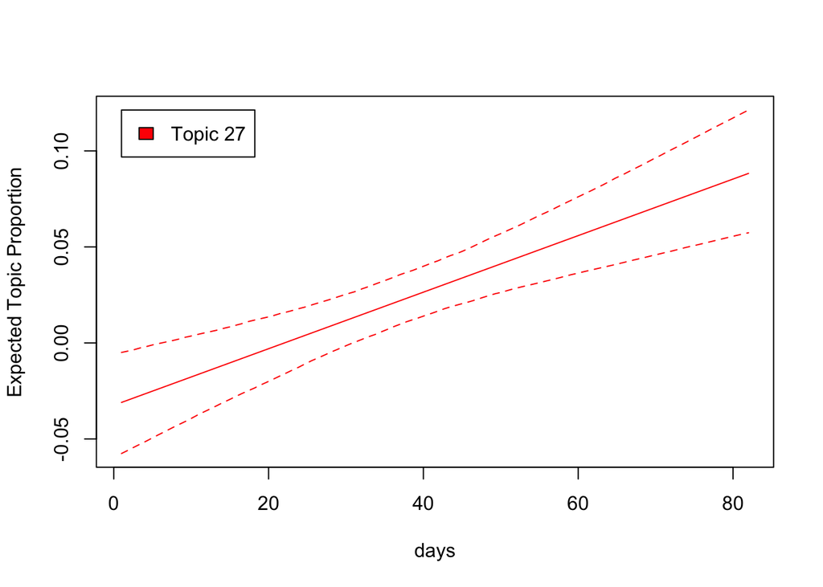

```r
# choose topic 27
day_effect<- estimateEffect(c(27) ~ day, stm_news, meta=news_q3_df)
plot(day_effect, covariate="day",model=stm_news, method="continuous", xlab="days")
```

### Q4

*Non-Parametric Scaling - Wordfish: Recall that the Wordfish algorithm allows us to scale political texts by a latent dimension. We will apply this function to analyze the UK manifestos.*

### Q4a

```r
# create a corpus that is the subset of the data corpus ukmanifestos
# that contains only speeches by the Conservative (‘Con’) and Labor (‘Lab’) parties
data4 <- data_corpus_ukmanifestos
data4_sub <- corpus_subset(data4,data4$documents$Party == 'Con' | data4$documents$Party == 'Lab')
```

### Q4b

```r
# estimate the latent left-right ideological dimension
data4_sub_df <- data.frame(data4_sub$documents)
lab <- which(data4_sub_df$Year == "1979" & data4_sub_df$Party == 'Lab')
con <- which(data4_sub_df$Year == "1979" & data4_sub_df$Party == 'Con')
uk_dfm <- dfm(data4_sub,remove_punct=TRUE,remove_number=TRUE,stem=TRUE, remove=stopwords("english"))
uk_tmwf <- textmodel_wordfish(uk_dfm, dir=c(lab, con))
summary(uk_tmwf)
```

[output not shown]

### Q4c

```r
df4 <- summary(uk_tmwf)
df4c <- data.frame(cbind(rownames(data4_sub_df),df4$estimated.document.positions$theta))
names(df4c) <- c("name", "result")
most_right_wing <- df4c[which.max(df4c$result),]
most_left_wing <- df4c[which.min(df4c$result),]
print(paste0("The most right wing is: ", most_right_wing$name))
```

```
## [1] "The most right wing is: UK_natl_2005_en_Con"
```

```r
print(paste0("The most left wing is: ", most_left_wing$name))
```

[output not shown]

### Q4d

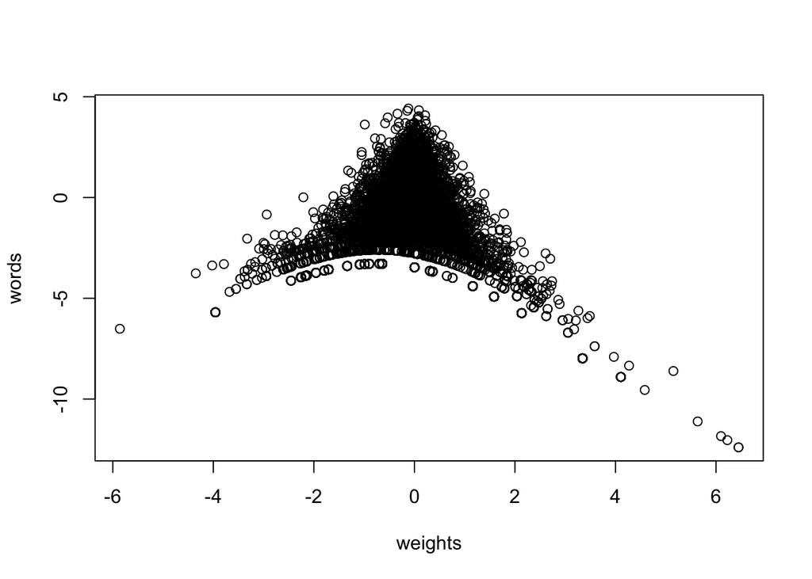

```r
# most important features--word fixed effects
words <- uk_tmwf$psi # values
names(words) <- uk_tmwf$features # the words
#sort(words)[1:50]
#sort(words, decreasing=T)[1:50]
# Guitar plot
weights <- uk_tmwf$beta
plot(weights, words)
```

**The x axis shows marginal word weights which is the word ability to discriminate between classes, y axis is the word fixed effects which shows the frequency of the words in general.**

### Q5

*Burstiness: Here we evaluate the burstiness of several words using the news data corpus of news headlines. To evaluate burstiness we will use the bursts package and the user-written function bursty from recitation that visualizes the results. You have been provided the news data corpus.*

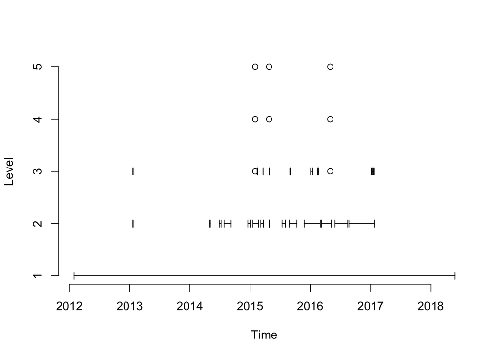

```
##    level      start        end
## 1      1 2018-05-26 2012-01-29
## 2      2 2017-01-22 2016-08-22
## 3      3 2017-01-21 2017-01-16
## 4      3 2017-01-12 2017-01-05
## 5      2 2016-08-15 2016-05-30
## 6      2 2016-05-07 2016-03-08
## 7      3 2016-05-01 2016-05-01
## 8      4 2016-05-01 2016-05-01
## 9      5 2016-05-01 2016-05-01
## 10     2 2016-03-02 2015-11-25
## 11     3 2016-02-21 2016-02-14
## 12     3 2016-01-17 2016-01-03
## 13     2 2015-10-12 2015-08-26
## 14     3 2015-09-02 2015-08-30
```

[output cut: 18 more lines]

```r
# 1  Loading bursty function: a repurposing of some guts of kleinberg()
bursty <- function(word, DTM, date) {
  word.vec <- DTM[, which(colnames(DTM) == word)]
  if(length(word.vec) == 0) {
    print(paste(word, " does not exist in this corpus."))
    return()
  }
  else {
    word.times <- c(0,which(as.vector(word.vec)>0))

    kl <- kleinberg(word.times, gamma = 0.5)
    kl$start <- date[kl$start+1]
    kl$end <- date[kl$end]
    max_level <- max(kl$level)

    plot(c(kl$start[1], kl$end[1]), c(1,max_level),
         type = "n", xlab = "Time", ylab = "Level", bty = "n",
         xlim = c(min(date), max(date)), ylim = c(1, max_level),
         yaxt = "n")
    axis(2, at = 1:max_level)

    for (i in 1:nrow(kl)) {
      if (kl$start[i] != kl$end[i]) {
        arrows(kl$start[i], kl$level[i], kl$end[i], kl$level[i], code = 3, angle = 90,
               length = 0.05)
      }
      else {
        points(kl$start[i], kl$level[i])
      }
    }

    print(kl)
  }
  #note deviation from standard defaults bec don't have that much data
}
# 2 Loading data
news_data <- readRDS("news_data.rds")
news_data <- data.frame(news_data)
news_data_corpus <- corpus(news_data$headline)
#get the date docvars
docvars(news_data_corpus)$date <- as.Date(as.character(news_data$date),"%Y-%m-%d")
dfm5 <- dfm(news_data_corpus)
# 3 Evaluating the burstiness of several key words
bursty("obama", dfm5, news_data_corpus$documents$date) #From around 2014 to 2017
```

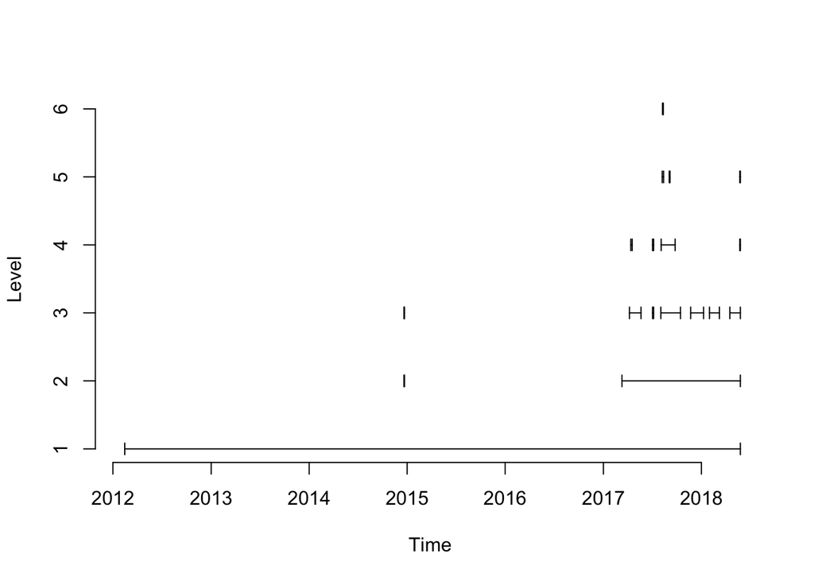

```
##    level      start        end
## 1      1 2018-05-26 2012-02-14
## 2      2 2018-05-26 2017-03-11
## 3      3 2018-05-26 2018-04-17
## 4      4 2018-05-26 2018-05-24
## 5      5 2018-05-26 2018-05-24
## 6      3 2018-03-09 2018-01-31
## 7      3 2018-01-09 2017-11-22
## 8      3 2017-10-15 2017-08-03
## 9      4 2017-09-25 2017-08-04
## 10     5 2017-09-06 2017-09-03
## 11     5 2017-08-13 2017-08-08
## 12     6 2017-08-12 2017-08-09
## 13     3 2017-07-07 2017-07-03
## 14     4 2017-07-07 2017-07-03
## 15     3 2017-05-21 2017-04-08
## 16     4 2017-04-18 2017-04-13
## 17     2 2014-12-22 2014-12-20
## 18     3 2014-12-22 2014-12-20
```

```r
bursty("korea", dfm5, news_data_corpus$documents$date) # concentrate on 2017-2018
```

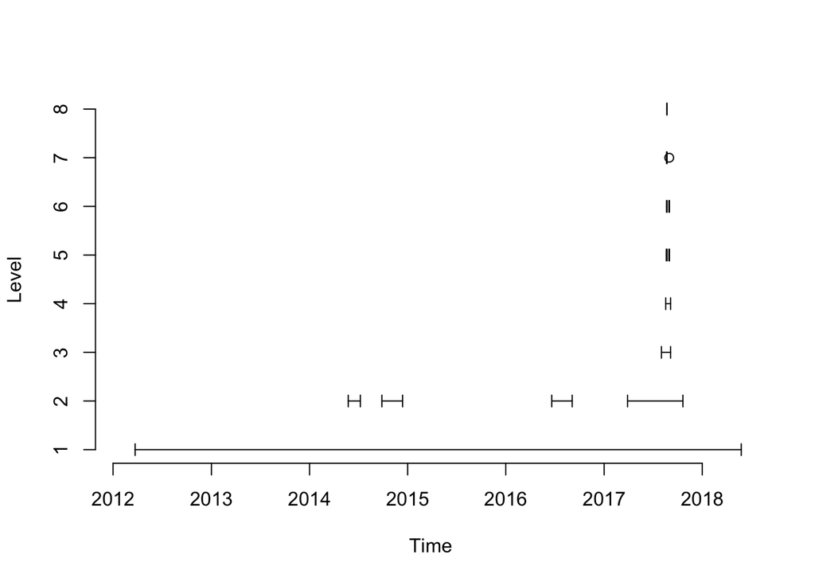

```
##    level      start        end
## 1      1 2018-05-26 2012-03-23
## 2      2 2017-10-21 2017-03-29
## 3      3 2017-09-05 2017-08-02
## 4      4 2017-09-05 2017-08-18
## 5      5 2017-09-01 2017-08-30
## 6      6 2017-09-01 2017-08-30
## 7      7 2017-08-31 2017-08-31
## 8      5 2017-08-23 2017-08-20
## 9      6 2017-08-23 2017-08-21
## 10     7 2017-08-23 2017-08-21
## 11     8 2017-08-23 2017-08-22
## 12     2 2016-09-04 2016-06-20
## 13     2 2014-12-13 2014-09-27
## 14     2 2014-07-09 2014-05-25
```

```r
bursty("afghanistan", dfm5, news_data_corpus$documents$date) # From 2017 - 2018 there is a obvious peak
```

**For “obama”, during 2009-2017, Obama is the 44th President of the United States.News and people had high level of attention to the word “obama”. The 2017–18 North Korea crisis was a period of heightened tension between North Korea and the United States throughout 2017. So pepele was focusing on the word “korea”. Fighting between Afghan government and Taliban forces intensified through 2017, causing high numbers of civilian casualties. So from 2017-2018, there are a lot of news about afghanistan.**

### Q6

*Dimension Reduction and Semantics: For this question use news data. To reduce computation time, use the first 1000 headlines from the “WORLD NEWS” category.*

### Q6a

```r
# Obtain the document feature matrix (DFM) of the corpus
news_data6 <- news_data[1:1000,]
news_data6_corpus <- corpus(news_data6,text_field="headline")
dfm6 <- dfm(news_data6_corpus,remove_punct=TRUE,tolower=TRUE,remove=stopwords("english"))
# Perform a principal components analysis
news_matrix <- convert(dfm6, to="matrix")
news_pca <- prcomp(news_matrix, center = TRUE, scale = TRUE)
# rank the words on the first principal component according to their loadings
loadings <- data.frame(news_pca$rotation)
# Report the top 5 with the most positive loadings and the top 5 with the most negative loadings
N <- 5
pc1_loading <- tibble(token = rownames(loadings), loading = as.vector(loadings[,1])) %>% arrange(-loading)
pc1_loading$loading <- scale(pc1_loading$loading, center = TRUE)
pc1_loading <- rbind(top_n(pc1_loading, N, loading),top_n(pc1_loading, -N, loading))
pc1_loading <- transform(pc1_loading, token = factor(token, levels = unique(token)))
pc1_loading
```

| token | loading |
| --- | --- |
| mostly | 20.0615814 |
| non-christian | 20.0615814 |
| militia | 20.0615814 |
| won | 20.0615814 |
| iraqi | 20.0615814 |
| christians | 20.0615814 |
| seats | 20.0615814 |
| intervene | 20.0615814 |
| cannes | -0.3003959 |
| black | -0.3080222 |

[output cut: 3 more lines]

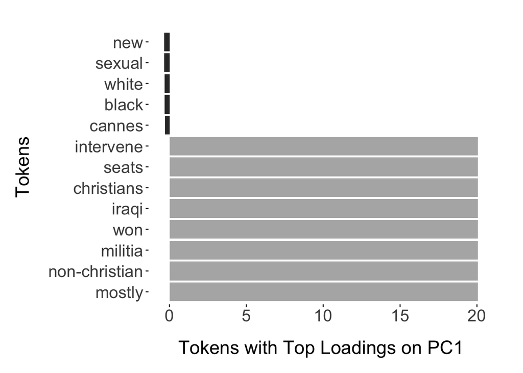

```r
# plot top tokens according to absolute loading values
ggplot(pc1_loading, aes(token, loading)) +
  geom_bar(stat = "identity", fill = ifelse(pc1_loading$loading <= 0, "grey20", "grey70")) +
  coord_flip() +
  xlab("Tokens") + ylab("Tokens with Top Loadings on PC1") +
  scale_colour_grey(start = .3, end = .7) +
  theme(panel.background = element_blank(),
        axis.text.x = element_text(size=16),
        axis.text.y = element_text(size=16),
        axis.title.y = element_text(size=18, margin = margin(t = 0, r = 15, b = 0, l = 15)),
        axis.title.x = element_text(size=18, margin = margin(t = 15, r = 0, b = 15, l = 0)),
        legend.text=element_text(size=16),
        legend.title=element_blank(),
        legend.key=element_blank(),
        legend.position = "top",
        legend.spacing.x = unit(0.25, 'cm'),
        plot.margin=unit(c(1,1,0,0),"cm"))
```

**The first principal component is interpretable. We can know the tokens with top loadings on the first principal component.**

### Q6b

```r
# Latent Semantic Analysis (LSA) aka Latent Semantic Indexing (LSI)
news_mat_lsa <- convert(dfm6, to = "lsa") # convert to transposed matrix (so terms are rows and columns are documents = TDM)
news_mat_lsa <- lw_logtf(news_mat_lsa) * gw_idf(news_mat_lsa) # local - global weighting (akin to TFIDF)
#1 Create LSA weights using TDM
news_lsa <- lsa(news_mat_lsa)
# lsa(myMatrix, dims = dimcalc_share(share = 0.8))
# share = fraction of the sum of the selected singular values over the sum of all singular values, default is 0.5
news_lsa_mat <- as.textmatrix(news_lsa)
#2 Check to see what a good number of dimensions is
?dimcalc_share
#3 report the 5 nearest tokens to america and corruption
america <- associate(news_lsa_mat, "america", "cosine", threshold = .0001)
america[1:5]
```

```
##      eyes      crow historian  childish gambino's
## 0.6646526 0.6646526 0.6646526 0.6331908 0.6331908
```

I did not stem the words in news_data. I tried corrupt it still didn’t work. I tried associate() and nearest_neighbors() for “corruption”. But: Error in textmatrix[term, ] : subscript out of bounds, also, Error in low_dim_space[query, , drop = FALSE] : subscript out of bounds. I changed the codes to comments temporarily.

```r
#corruption <- associate(news_lsa_mat, "corruption", "cosine", threshold = .0001)
#corruption[1:5]
```

```r
#corrupt <- associate(news_lsa_mat, "corrupt", "cosine", threshold = .0001)
#corrupt[1:5]
```

```r
# nearest_neighbors()
# function computes cosine similarity between query and all documents and returns N most similar
nearest_neighbors <- function(query, low_dim_space, N = 5, norm = "l2"){
  cos_sim <- sim2(x = low_dim_space, y = low_dim_space[query, , drop = FALSE], method = "cosine", norm = norm)
  nn <- cos_sim <- cos_sim[order(-cos_sim),]
  return(names(nn)[2:(N + 1)])  # query is always the nearest neighbor hence dropped
}

# apply to document retrieval
#nearest_neighbors(query = "corruption", low_dim_space = SOTU_pca$x, N = 5, norm = "l2")
```

### Q6c

```r
glove <- readRDS("glove.rds")
nearest_neighbors <- function(cue, embeds, N = 5, norm = "l2"){
  cos_sim <- sim2(x = embeds, y = embeds[cue, , drop = FALSE], method = "cosine", norm = norm)
  nn <- cos_sim <- cos_sim[order(-cos_sim),]
  return(names(nn)[2:(N + 1)])  # cue is always the nearest neighbor hence dropped
}
print("five nearest neighbors for america are:")
```

```
## [1] "five nearest neighbors for america are:"
```

```r
nearest_neighbors("america", glove)
```

```
## [1] "europe"   "american" "nation"   "states"   "latin"
```

```r
print("five nearest neighbors for corruption are:")
```

```
## [1] "five nearest neighbors for corruption are:"
```

```r
nearest_neighbors("corruption", glove)
```

```
## [1] "graft"       "bribery"     "corrupt"     "allegations" "scandals"
```